# Tarea 5

### Autor: Guillermo Fonseca

### Fecha: 13/09/2020

### Asignatura: REDES NEURONALESAVANZADAS DE APRENDIZAJE PROFUNDO IMA543

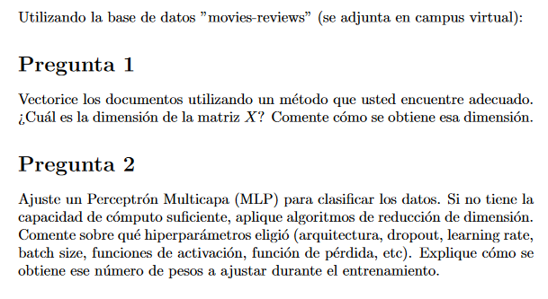

## Cargar documentos

```python
import pandas as pd
df_documents = pd.read_csv("movies_reviews.csv")
df_documents
```

|  | review | sentiment |
| --- | --- | --- |
| 0 | In 1974, the teenager Martha Moxley (Maggie Gr... | 1 |
| 1 | OK... so... I really like Kris Kristofferson a... | 0 |
| 2 | ***SPOILER*** Do not read this, if you think a... | 0 |
| 3 | hi for all the people who have seen this wonde... | 1 |
| 4 | I recently bought the DVD, forgetting just how... | 0 |
| ... | ... | ... |
| 49995 | OK, lets start with the best. the building. al... | 0 |
| 49996 | The British 'heritage film' industry is out of... | 0 |
| 49997 | I don't even know where to begin on this one. ... | 0 |
| 49998 | Richard Tyler is a little boy who is scared of... | 0 |
| 49999 | I waited long to watch this movie. Also becaus... | 1 |

50000 rows × 2 columns

```python
corpus = df_documents.values.T[0]
labels = df_documents.values.T[1]
```

## Tokenizacion

### Ejemplos de tokens en el texto

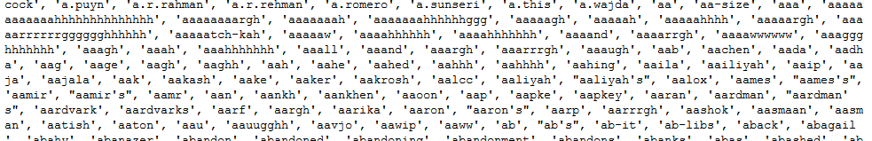

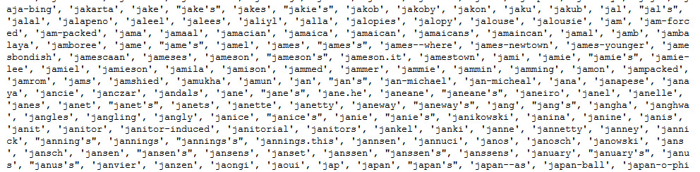

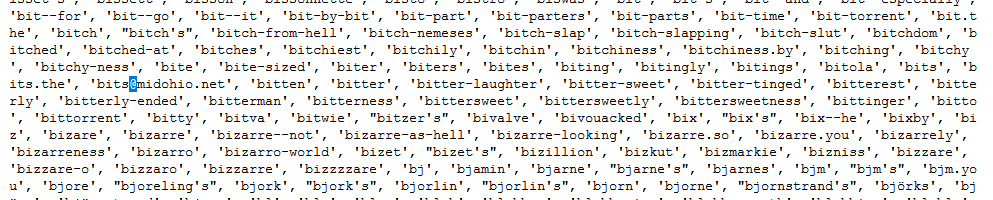

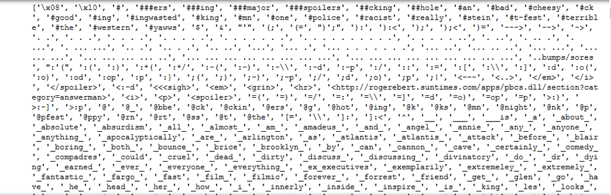

```python
from nltk.util import ngrams
from nltk.tokenize.casual import casual_tokenize
from nltk.stem.porter import PorterStemmer
from nltk import SnowballStemmer
import re
import nltk
import numpy as np

nltk.download('stopwords')

stopwords = nltk.corpus.stopwords.words('english')

puntuacion = set((',', '.', '--', '-', '¡', '!', '¿', '?', ':', ';', '``', "''", '(', ')', '[', ']', '«',
                  '»', '/', '—', '_', '..', '+', '…', '‘', '’', '–', '%', '“', '”', '″', '"', '·', '|',
                  '<', '>', '=', '*', '°', "'", '___', '{', ':}', '...', '', '^', '`', ' '))

remove_from_text = ['<br /><br />', '', "'s", '<SPOILER>', '</SPOILER>', '<p>', '<em>', '</em>', '<i>', '</i>',
                      '<hr>', '<grin>', '<spoiler>', '</spoiler>']

token_removal_characters = ['@', '.com', 'www', '#', '=', '<', '>', 'http']

class tokenizacion:
    def __init__(self,
                 text_remove=1,   reduce_len=1, strip_handles=1,
                 stopwords=1, puntuacion=1, numbers=1,
                 token_remove=1):

        # Eliminamos caracteres del texto que no se tokenizan bien
        self.text_remove = text_remove

        # Reducimos el largo de palabras que repiten caracteres
        self.reduce_len = reduce_len

        # Quitamos @handles de twitter
        self.strip_handles = strip_handles

        # Eliminar stopwords
        self.delete_stopwords = stopwords

        # Eliminar puntuacion
        self.delete_puntuacion = puntuacion

        # Eliminar numeros
        self.delete_numbers = numbers

        # Eliminamos tokens que contengan caracteres
        self.delete_token_remove = token_remove


    def tokenize(self, document):

        # Eliminamos caracteres del texto que no se tokenizan bien
        if self.text_remove:
            for ch in remove_from_text:
                document = document.replace(ch, " ")

        # Normalizamos y tokenizamos
        tokens = casual_tokenize(document.lower(), reduce_len=self.reduce_len, strip_handles=self.strip_handles)

        # Eliminamos tokens que contengan los siguientes caracteres
        if self.delete_token_remove:
            for ch in token_removal_characters:
                tokens = [x for x in tokens if ch not in x]

        # Separamos tokens divididos por puntos
        y=[]
        for token in tokens:
            y = y + token.split('.')
        tokens = y

        # Separamos tokens divididos por guiones bajos
        y=[]
        for token in tokens:
            y = y + token.split('_')
        tokens = y

        # Eliminamos stopwords
        if self.delete_stopwords:
            tokens = [x for x in tokens if x not in stopwords]
        # Eliminamos puntuacion
        if self.delete_puntuacion:
            tokens = [x for x in tokens if x not in puntuacion]

        # Eliminamos numeros
        if self.delete_numbers:
            tokens = [x for x in tokens if not re.search(r'\d', x)]

        return tokens
```

```python
string = "This is supposed to be based on Wilkie Collins' _The_Woman_In_White_, but the only resemblance it bore to that story were the characters' names, the time period, and the settings. If they were going to change the story so thoroughly, I don't understand why they needed to keep up the pretense that it came from Wilkie Collins. Go read the book. It's much better."
string = "I work at a nuclear power plant, so I am getting a kick out of these replies.<br /><br />Seriously, I do. Go to http://en.wikipedia.org/wiki/Palisades_Nuclear_Generating_Station and you can see where I work.<br /><br />I could not think of a safer industry to work in. We are required by procedures to report events as minor as paper cuts. Any issue identified as being a potential concern with respect to nuclear, radiological, or industrial safety is immediately reported in the corrective action process.<br /><br />Bottom line is that nuclear plants in the US operate with safety in the front of their mind."
string = "This movie could had been an interesting character study and could had given some insight on its subject but real problem with this movie is that it doesn't have any of this in it. It doesn't give any insight-, or solutions to the problem. It's just the portrayal of 'old' male sex addict and the problems this is creating for his every day normal life and family. Why would you want to watch this? It's all so totally pointless and meaningless.<br /><br />It also really doesn't help that the main character is some wrinkly 50+ year old male. You'll have a hard time identifying yourself- and sympathize for him. He just seems like a dirty old playboy, who is an a constant hunt for woman and sex. He has all kinds of sexual intercourse's about 3 times a day with different woman and not just only with prostitutes.<br /><br />It also doesn't have a bad visual style, though it all feels a bit forced. But nevertheless it's all better looking than most other direct-to-video productions. Who knows, if the film-makers had been given better material to work with, the movie would had deserved a better faith.<br /><br />The story really gets ridicules at times. There are really some pointless plot-lines that are often more laughable than they were obviously supposed to be. I'm talking about for instance the whole Ordell plot-line. Things get worse once they movie starts heading toward the ending. Also the whole way the story is being told, cutting back and forth between the events that happened and the main character's sessions with his psychiatrist feels a bit cheap and simple.<br /><br />But as far as bad movies are concerned, this just isn't one of them. It's not really any better or worse than any other random straight-to-video flick, with similar concepts.<br /><br />Still seems weird and quite amazing that they managed to cast Nastassja Kinski and Ed Begley Jr. in such a simple small insignificant production as this one is. Guess they were really desperate for work and money.<br /><br />4/10"
tokenizer = tokenizacion(text_remove=1, reduce_len=0, strip_handles=0,
                         stopwords=0, puntuacion=1, numbers=0, token_remove=1).tokenize
tokens = tokenizer(string)
tokens
```

```
['this',
 'movie',
 'could',
 'had',
 'been',
 'an',
 'interesting',
 'character',
 'study',
 'and',
 'could',
 'had',
 'given',
 'some',
 'insight',
 'on',
 'its',
 'subject',
 'but',
 'real',
 'problem',
 'with',
 'this',
 'movie',
 'is',
 'that',
 'it',
 "doesn't",
 'have',
 'any',
 'of',
 'this',
 'in',
 'it',
 'it',
 "doesn't",
 'give',
 'any',
 'insight',
 'or',
```

[output cut: 284 more lines]

```
 'production',
 'as',
 'this',
 'one',
 'is',
 'guess',
 'they',
 'were',
 'really',
 'desperate',
 'for',
 'work',
 'and',
 'money',
 '4/10']
```

## Vectorizacion

```python
from sklearn.feature_extraction.text import TfidfVectorizer
from sklearn.feature_extraction.text import CountVectorizer
from sklearn.preprocessing import MinMaxScaler

#tokenizer = tokenizacion(text_remove=1, reduce_len=1, strip_handles=1,
#                         stopwords=0, puntuacion=1, numbers=1, token_remove=1).tokenize
tokenizer = tokenizacion(text_remove=1, reduce_len=0, strip_handles=0,
                         stopwords=0, puntuacion=1, numbers=0, token_remove=1).tokenize
#vectorizer = CountVectorizer(min_df=0.005, encoding='utf-8', tokenizer=tokenizer)
vectorizer = TfidfVectorizer(min_df=0.002, encoding='utf-8', tokenizer=tokenizer)#min_df=0.002
```

```python
X = vectorizer.fit_transform(corpus).toarray()
```

```python
num_tokens = X.shape[1]
num_docs = X.shape[0]
print(f"Observamos {num_docs} documentos y {num_tokens} tokens")
X.shape
```

```
Observamos 50000 documentos y 6340 tokens
```

```
(50000, 6340)
```

```python
X = MinMaxScaler().fit_transform(X.reshape(-1,1))
X = X.reshape(num_docs, num_tokens)
```

```python
print(vectorizer.get_feature_names())
```

```
['$', '&', '):', ');', '0', '00', '1', '1/10', '1/2', '10', '10/10', '100', '101', '11', '12', '13', '13th', '14', '15', '16', '17', '18', '19', '1930', '1930s', '1939', '1940', '1940s', '1945', '1950', '1950s', '1959', '1960', '1960s', '1968', '1969', '1970', '1970s', '1971', '1972', '1973', '1974'…
```

## Reduccion de la dimensión

```python
#from sklearn.decomposition import TruncatedSVD

#svd = TruncatedSVD(n_components=256, n_iter=50) se queda pegado en 50%
#svd = TruncatedSVD(n_components=2^7, n_iter=50)
#svd_vectors = svd.fit_transform(X)
```

### Alternativa con tensorflow

```python
#from tensorflow.linalg import svd
#
#s = svd(X.toarray()., compute_uv=False)
#X
```

```python
#svd_vectors.shape
```

```python
#print(np.min(svd_vectors))
#print(np.max(svd_vectors))
```

```python
#svd_vectors_scale = MinMaxScaler().fit_transform(svd_vectors.reshape(-1,1))
#print(np.min(svd_vectors_scale))
#print(np.max(svd_vectors_scale))
#svd_vectors_scale = svd_vectors_scale.reshape(svd_vectors.shape[0], svd_vectors.shape[1])
#print(svd_vectors_scale.shape)
```

## Test y train

```python
from sklearn.model_selection import train_test_split

x_train, x_test, y_train, y_test = train_test_split(X, labels, test_size=0.1#0.2
                                                   ,random_state=5#271828
                                                    , stratify=labels)
```

```python
print(f"Hay {labels.sum()} reseñas positivas en el corpus")
print(f"Hay {y_test.sum()} reseñas positivas en el set de test")
print(f"Hay {y_train.sum()} reseñas positivas en el set de train")
num_labels = len(np.unique(y_train))
```

```
Hay 25000 reseñas positivas en el corpus
Hay 2500 reseñas positivas en el set de test
Hay 22500 reseñas positivas en el set de train
```

```python
print(np.min(x_test))
print(np.max(x_test))
```

```
0.0
0.9286323952088882
```

```python
print(np.min(x_train))
print(np.max(x_train))
```

```
0.0
0.9999999999999999
```

```python
from keras.utils import to_categorical
# Convertimos los labels en vectores one-hot
y_train = to_categorical(y_train)
y_test = to_categorical(y_test)
```

## Red Neuronal

```python
input_size = num_tokens#x_train.shape[1]

# hiperparametros
batch_size = 256#256
hidden_units = 16*20#16*5#16*4mejor#256*2#256#128#64#32#16
dropout = 0.45#0.3
epochs = 15
```

```
Model: "sequential_1"
_________________________________________________________________
Layer (type)                 Output Shape              Param #
=================================================================
dense_5 (Dense)              (None, 320)               2029120
_________________________________________________________________
activation_5 (Activation)    (None, 320)               0
_________________________________________________________________
dropout_4 (Dropout)          (None, 320)               0
_________________________________________________________________
dense_6 (Dense)              (None, 320)               102720
_________________________________________________________________
activation_6 (Activation)    (None, 320)               0
_________________________________________________________________
dropout_5 (Dropout)          (None, 320)               0
_________________________________________________________________
dense_7 (Dense)              (None, 320)               102720
_________________________________________________________________
activation_7 (Activation)    (None, 320)               0
_________________________________________________________________
dropout_6 (Dropout)          (None, 320)               0
_________________________________________________________________
dense_8 (Dense)              (None, 320)               102720
_________________________________________________________________
activation_8 (Activation)    (None, 320)               0
_________________________________________________________________
dropout_7 (Dropout)          (None, 320)               0
_________________________________________________________________
dense_9 (Dense)              (None, 2)                 642
_________________________________________________________________
activation_9 (Activation)    (None, 2)                 0
=================================================================
Total params: 2,337,922
Trainable params: 2,337,922
Non-trainable params: 0
_________________________________________________________________
```

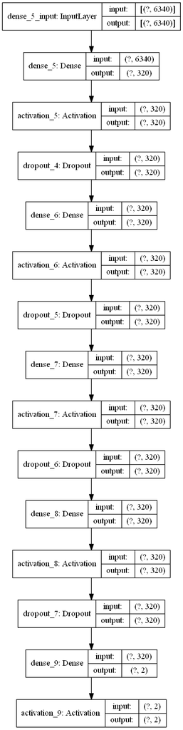

```python
from tensorflow.keras.models import Sequential
from tensorflow.keras.layers import Dense, Activation, Dropout
from tensorflow.keras.utils import plot_model

model = Sequential()

# Primera
model.add(Dense(hidden_units, input_dim=input_size))
model.add(Activation('relu'))
model.add(Dropout(dropout))

# Segunda
model.add(Dense(hidden_units))#/2))
model.add(Activation('relu'))
model.add(Dropout(dropout))

# Tercera
model.add(Dense(hidden_units))#/4))
model.add(Activation('relu'))
model.add(Dropout(dropout))

# Cuarta
model.add(Dense(hidden_units))#/8))
model.add(Activation('relu'))
model.add(Dropout(dropout))

# Quinta
#model.add(Dense(hidden_units/16))
#model.add(Activation('relu'))
#model.add(Dropout(dropout))

# Ultima
model.add(Dense(num_labels))
model.add(Activation('softmax'))
model.summary()
plot_model(model, show_shapes=True, show_layer_names=True)
```

```python
#compilamos
model.compile(loss='binary_crossentropy' , optimizer='adam', metrics=['accuracy'])
```

```python
history = model.fit(x_train, y_train, batch_size=batch_size, epochs=epochs, validation_data=(x_test, y_test))
loss, acc = model.evaluate(x_test, y_test, batch_size=batch_size)
print("\n Test accuracy: %.1f%%" % (100.0 * acc))
```

```
 Test accuracy: 89.5%
```

3 capas y 15 epocas, 16*5 hidden units

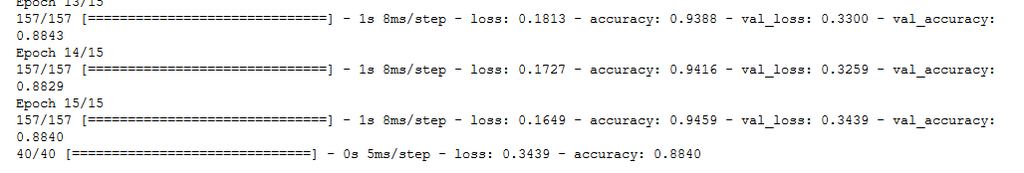

3 capas y 20 epocas, 16*5 hidden units

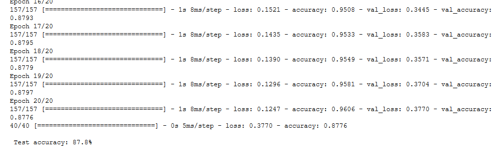

4 capas y 20 epocas, 16*5 hidden units

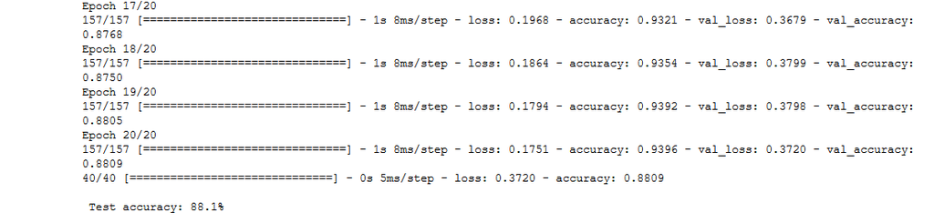

4 capas y 50 epocas, 16*5 hidden units

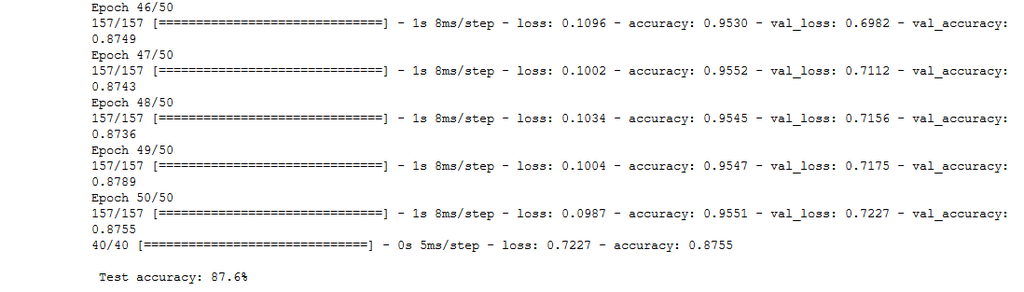

5 capas y 50 epocas, 16*5 hidden units

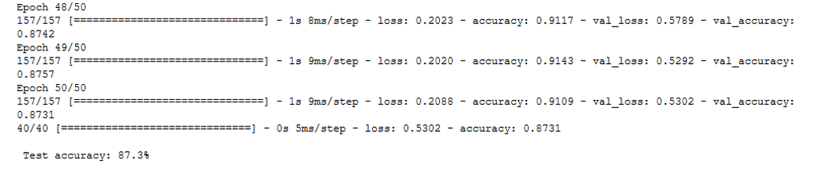

5 capas y 50 epocas, 16*6 hidden units

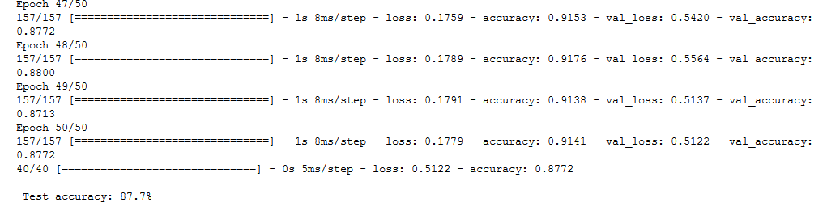

5 capas y 50 epocas, 16*10 hidden units

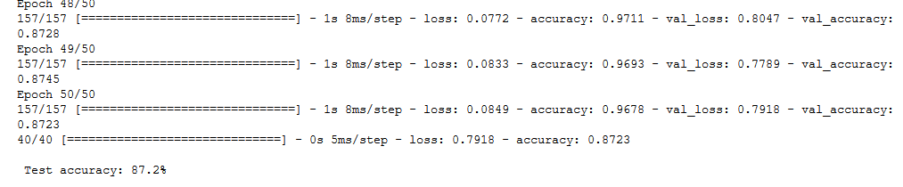

4 capas y 50 epocas, 16*10 hidden units

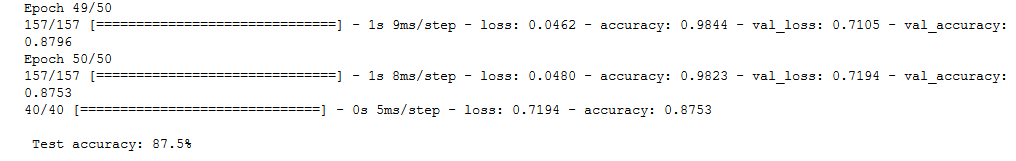

4 capas y 50 epocas, 16*20 hidden units

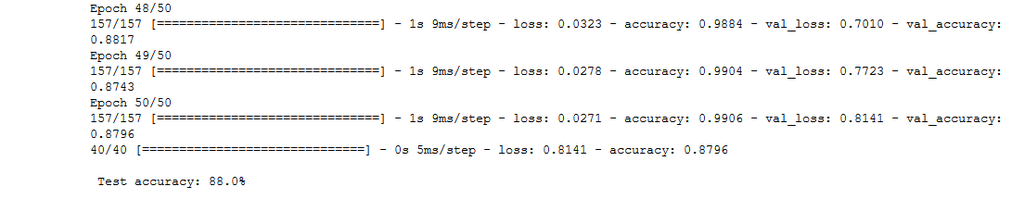

4 capas y 50 epocas, 16*20 hidden units, se cambio softmax por relu

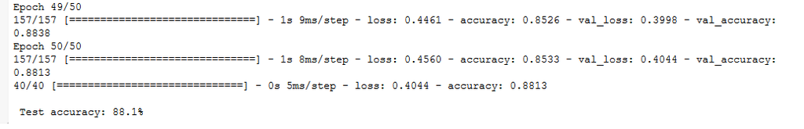

4 capas y 50 epocas, 16*20 hidden units, se cambio binary a categorical cross entropy

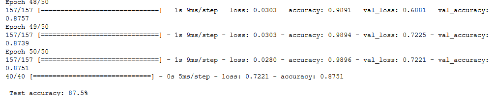

4 capas y 50 epocas, 16*20 hidden units, se cambio dropout de 0.45 a 0.3

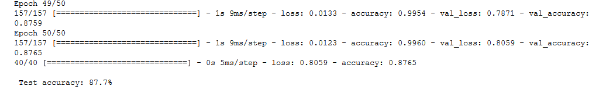

4 capas y 50 epocas, 16*20 hidden units, se cambio a test_size de 0.2 a 0.4 ,random_state de 271828 a 5

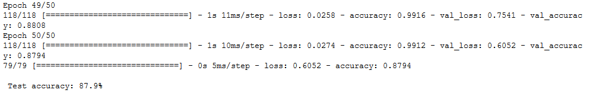

4 capas y 50 epocas, 16*20 hidden units, se cambio a test_size de 0.2 a 0.4 ,random_state de 271828 a 5, ademas se cambio countvectorizer a tfidfvectorizer

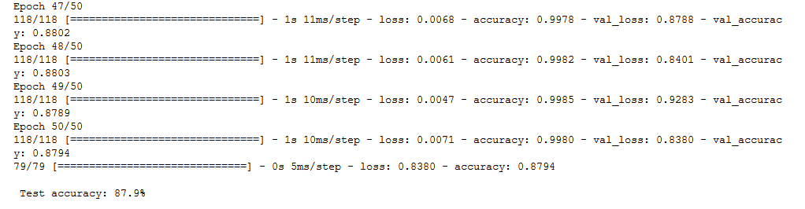

4 capas y 50 epocas, 16*20 hidden units, se cambio a test_size de 0.2 a 0.4 ,random_state de 271828 a 5, ademas se cambio countvectorizer a tfidfvectorizer, sin disminución progresiva

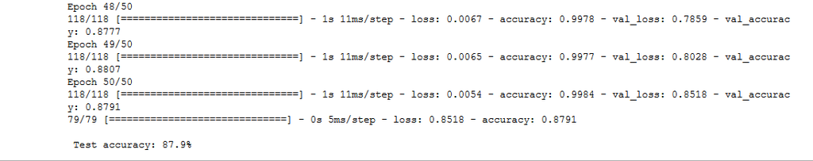

4 capas y 50 epocas, 16*20 hidden units, se cambio a test_size de 0.2 a 0.1 ,random_state de 271828 a 5, ademas se cambio countvectorizer a tfidfvectorizer, sin disminución progresiva

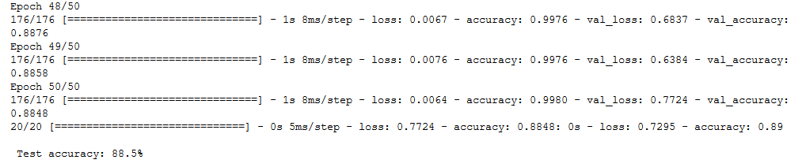

4 capas y 50 epocas, 16*20 hidden units, se cambio a test_size de 0.2 a 0.1 ,random_state de 271828 a 5, ademas se cambio countvectorizer a tfidfvectorizer, sin disminución progresiva , NO se le quitan los numeros

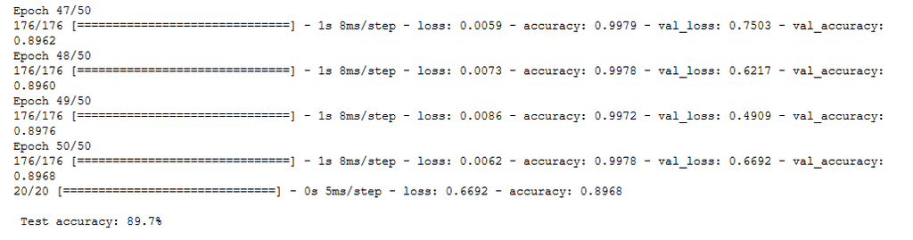

4 capas y 50 epocas, hidden units igual al numero de tokens, se cambio a test_size de 0.1, random_state de 5, ademas se usa tfidfvectorizer, sin disminución progresiva , NO se le quitan los numeros

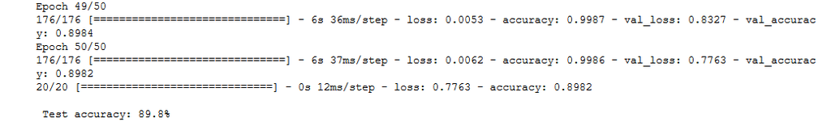

4 capas y 15 epocas, 16*20 hidden unit, test_size de 0.1, random_state de 5, ademas se usa tfidfvectorizer, sin disminución progresiva , NO se le quitan los numeros min_df de 0.002

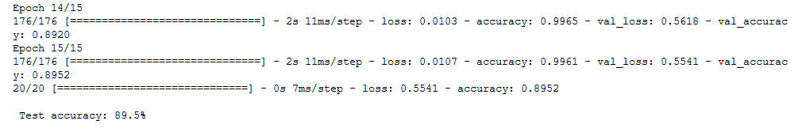

## Guardar Modelo

```python
model_structure = model.to_json()
with open("mlp_model.json", "w") as json_file:
    json_file.write(model_structure)
model.save_weights("mlp_weights.h5")
```

## Grafico de comportamieno durante entrenamiento

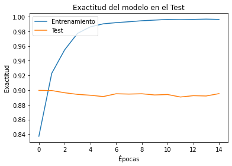

```python
import matplotlib.pyplot as plt

plt.plot(history.history['accuracy'])
plt.plot(history.history['val_accuracy'])
plt.title("Exactitud del modelo en el Test")
plt.ylabel('Exactitud')
plt.xlabel('Épocas')
plt.legend(['Entrenamiento', 'Test'], loc='upper left')
plt.show()
```

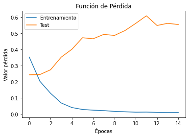

```python
plt.plot(history.history['loss'])
plt.plot(history.history['val_loss'])
plt.title("Función de Pérdida")
plt.ylabel('Valor pérdida')
plt.xlabel('Épocas')
plt.legend(['Entrenamiento', 'Test'], loc='upper left')
plt.show()
```